# Results_NEW_ALL

Sean Dimoff

27/05/20

**Exploratory Plots for 2017-2018 Acoustic/Fish Data**

**Purpose** To run and select my new final models for the acoustic manuscript

I have summarized results at the top here, but please scroll down if you would like to see the outputs of the linear models and further analysis into each of the selected models.

*Note*

Any models that use MF - are actually my low frequency models - this is just an artifact from the beginning of the project.

fishing pressure has now been centered.

In the low frequencies, Lunar phase category “First Quarter” cannot be analyzed because it is the only category of lunar phase in 2018 and therefore they are collinear.

# Results Summarized

**SPL HF**

The selected model was the “best” model according to AIC. It included:

*Snaps x Day/Night + lunar phase + Year + fishing pressure*

All were significant.

It explains 37.14% of the variation in HF SPL.

**SPL LF**

The selected model was not the “best” model according to AIC.

The “best” model was maximal. But the selected model was within delta AIC < 2 and had several fewer df.

This selected model included:

*Knocks x Hour + Herbivory + Year + Lunar Phase + fishing pressure*

The interaction between knocks and 9AM was the only significant interaction and was strongly positive.

Herbivory was significant as well with a small positive effect.

Year was also significant.

Lunar phase and fishing pressure were not significant.

This model explains 53% of variation in LF SPL.

**ACI HF**

The selected model was not the “best” model according to AIC.

All 3 models were within delta AIC <2. So I chose the model with the fewest df. It was the only model that didn’t include day/night (which was not significant in any models).

The chosen model included:

*Snaps + Year + lunar phase + fishing pressure*

Only snaps and fishing pressure were significant.

Snaps had a really small effect size, fishing pressure was larger.

The model is significant but probably due to the enormous sample size (n > 15,000)

This model only explained 7.5% of variation in ACI.

**ACI LF**

The selected model was the “best” model according to AIC.

One other similar model fell within delta AIC < 4, but it had 2 more df (it included herbivory and long calls).

Neither model is significant however.

The chosen model included:

*Knocks + Hour + Year + lunar phase + fishing pressure*

Within the chosen model only knocks were significant, with a reasonable effect size (~3000).

This model only explains 1.2% of variation in LF ACI.

# Final Model selection

## SPL HF Model

```r
Snap.HF$Year <- as.character(Snap.HF$Year)

simple.model <- lm(SPL_HF ~ Snaps + Year + lunar.phase.sine + fp.cont, data = Snap.HF)
summary(simple.model)
```

```
##
## Call:
## lm(formula = SPL_HF ~ Snaps + Year + lunar.phase.sine + fp.cont,
##     data = Snap.HF)
##
## Residuals:
##     Min      1Q  Median      3Q     Max
## -8.2542 -2.1308  0.1111  1.9581 13.5791
##
## Coefficients:
##                   Estimate Std. Error  t value Pr(>|t|)
## (Intercept)      115.84784    0.02913 3977.289  < 2e-16 ***
## Snaps              1.55814    0.04694   33.197  < 2e-16 ***
## Year2018           3.41461    0.04829   70.717  < 2e-16 ***
## lunar.phase.sine   0.19957    0.04728    4.221 2.45e-05 ***
## fp.cont            0.87347    0.04693   18.612  < 2e-16 ***
## ---
## Signif. codes:  0 '***' 0.001 '**' 0.01 '*' 0.05 '.' 0.1 ' ' 1
##
## Residual standard error: 2.936 on 15982 degrees of freedom
## Multiple R-squared:  0.2923, Adjusted R-squared:  0.2921
## F-statistic:  1650 on 4 and 15982 DF,  p-value: < 2.2e-16
```

```r
simple.model1<- lm(SPL_HF ~ Snaps + dn + Year + lunar.phase.sine + fp.cont, data = Snap.HF)
```

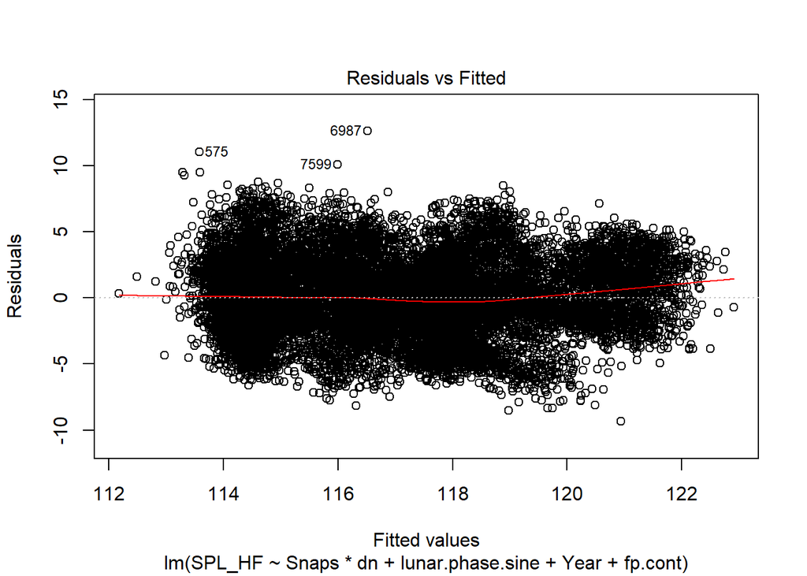

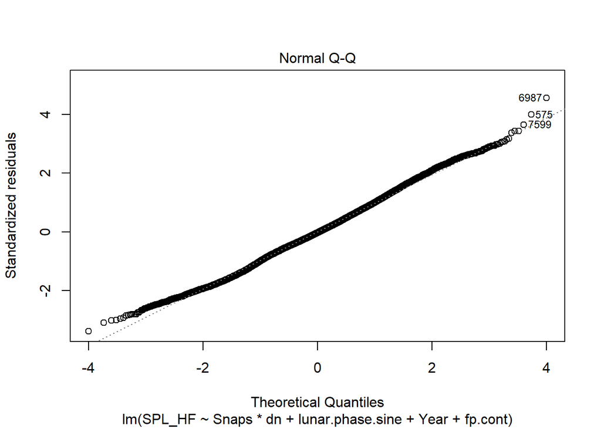

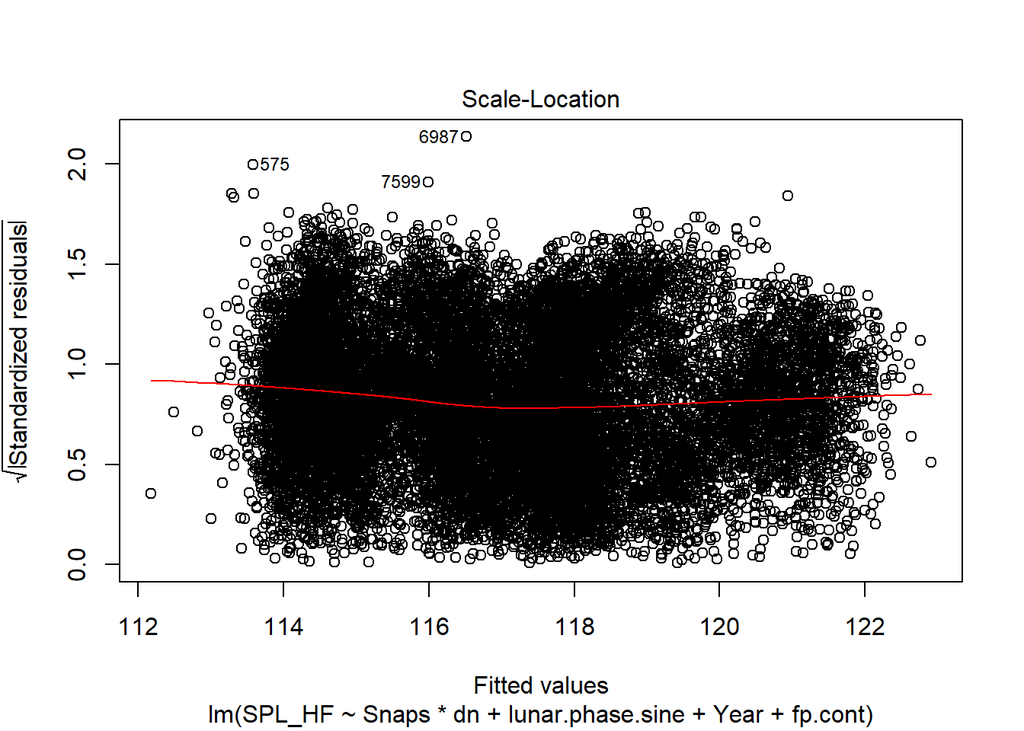

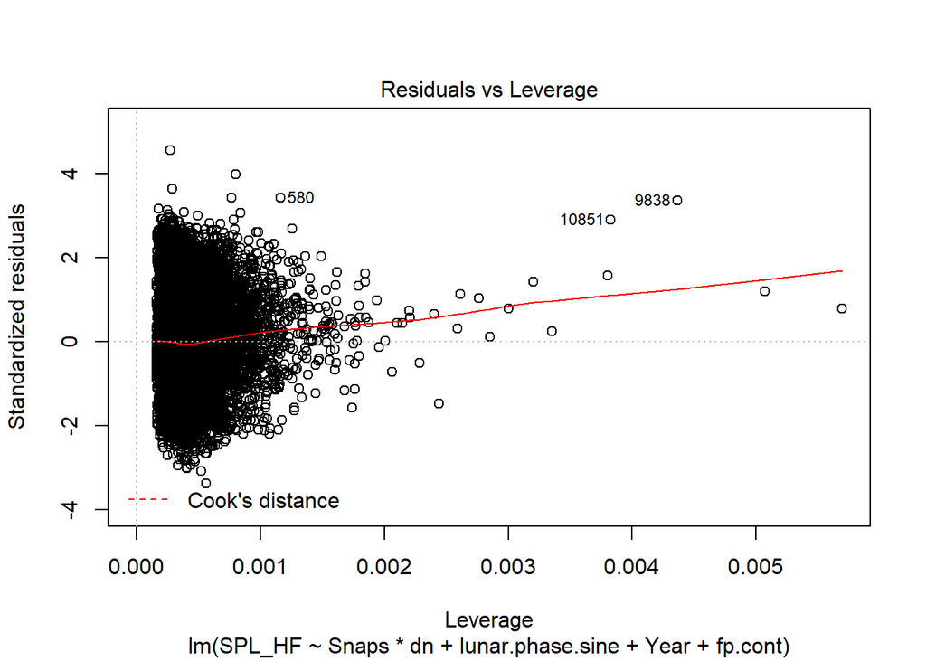

```r
simple.model3 <- lm(SPL_HF ~ Snaps*dn + lunar.phase.sine + Year + fp.cont, data = Snap.HF)
plot(simple.model3)
```

### Model Selection

```r
#coming up with several variations on the models presented above

#testing each of the models

splhftbl <- AICc(simple.model, simple.model1, simple.model3)

splhftbl$minAIC <- 77923.39
splhftbl$deltaAIC <- splhftbl$AICc - splhftbl$minAIC

splhftbl
```

```
##               df     AICc   minAIC     deltaAIC
## simple.model   6 79819.11 77923.39 1.895717e+03
## simple.model1  7 78034.51 77923.39 1.111151e+02
## simple.model3  8 77923.39 77923.39 5.004122e-04
```

```r
summary(simple.model)
```

```
##
## Call:
## lm(formula = SPL_HF ~ Snaps + Year + lunar.phase.sine + fp.cont,
##     data = Snap.HF)
##
## Residuals:
##     Min      1Q  Median      3Q     Max
## -8.2542 -2.1308  0.1111  1.9581 13.5791
##
## Coefficients:
##                   Estimate Std. Error  t value Pr(>|t|)
## (Intercept)      115.84784    0.02913 3977.289  < 2e-16 ***
## Snaps              1.55814    0.04694   33.197  < 2e-16 ***
## Year2018           3.41461    0.04829   70.717  < 2e-16 ***
## lunar.phase.sine   0.19957    0.04728    4.221 2.45e-05 ***
## fp.cont            0.87347    0.04693   18.612  < 2e-16 ***
## ---
## Signif. codes:  0 '***' 0.001 '**' 0.01 '*' 0.05 '.' 0.1 ' ' 1
##
## Residual standard error: 2.936 on 15982 degrees of freedom
## Multiple R-squared:  0.2923, Adjusted R-squared:  0.2921
## F-statistic:  1650 on 4 and 15982 DF,  p-value: < 2.2e-16
```

```r
summary(simple.model1)
```

```
##
## Call:
## lm(formula = SPL_HF ~ Snaps + dn + Year + lunar.phase.sine +
##     fp.cont, data = Snap.HF)
##
## Residuals:
##     Min      1Q  Median      3Q     Max
## -9.1177 -1.8066 -0.0377  1.7997 12.5081
##
## Coefficients:
##                   Estimate Std. Error  t value Pr(>|t|)
## (Intercept)      114.95513    0.03436 3345.764  < 2e-16 ***
## Snaps              1.28707    0.04482   28.714  < 2e-16 ***
## dnNight            1.93487    0.04451   43.469  < 2e-16 ***
## Year2018           3.42839    0.04566   75.078  < 2e-16 ***
## lunar.phase.sine   0.20773    0.04471    4.646 3.42e-06 ***
## fp.cont            0.91688    0.04439   20.654  < 2e-16 ***
## ---
## Signif. codes:  0 '***' 0.001 '**' 0.01 '*' 0.05 '.' 0.1 ' ' 1
##
## Residual standard error: 2.777 on 15981 degrees of freedom
## Multiple R-squared:  0.3671, Adjusted R-squared:  0.3669
## F-statistic:  1854 on 5 and 15981 DF,  p-value: < 2.2e-16
```

```r
summary(simple.model3)
```

```
##
## Call:
## lm(formula = SPL_HF ~ Snaps * dn + lunar.phase.sine + Year +
##     fp.cont, data = Snap.HF)
##
## Residuals:
##    Min     1Q Median     3Q    Max
## -9.360 -1.801 -0.091  1.811 12.626
##
## Coefficients:
##                   Estimate Std. Error  t value Pr(>|t|)
## (Intercept)      114.94053    0.03427 3354.404  < 2e-16 ***
## Snaps              0.87152    0.05930   14.696  < 2e-16 ***
## dnNight            1.91938    0.04438   43.249  < 2e-16 ***
## lunar.phase.sine   0.21242    0.04456    4.767 1.89e-06 ***
## Year2018           3.39625    0.04560   74.472  < 2e-16 ***
## fp.cont            1.00378    0.04498   22.314  < 2e-16 ***
## Snaps:dnNight      0.97433    0.09147   10.652  < 2e-16 ***
## ---
## Signif. codes:  0 '***' 0.001 '**' 0.01 '*' 0.05 '.' 0.1 ' ' 1
##
## Residual standard error: 2.767 on 15980 degrees of freedom
## Multiple R-squared:  0.3716, Adjusted R-squared:  0.3714
## F-statistic:  1575 on 6 and 15980 DF,  p-value: < 2.2e-16
```

## ACI HF Model

```r
aci.hf <- lm(ACI_HF ~ Snaps*dn + Year + lunar.phase.sine + fp.cont, data = Snap.HF)
aci.hf1 <- lm(ACI_HF ~ Snaps + Year + lunar.phase.sine + fp.cont, data = Snap.HF)
aci.hf2 <- lm(ACI_HF ~ Snaps+ dn + Year + lunar.phase.sine + fp.cont, data = Snap.HF)


acihftbl <- AICc(aci.hf, aci.hf1, aci.hf2)
acihftbl$minAIC <- 319647.7
acihftbl$deltaAIC <- acihftbl$AICc - acihftbl$minAIC
acihftbl
```

```
##         df     AICc   minAIC   deltaAIC
## aci.hf   8 319647.7 319647.7 0.04977515
## aci.hf1  6 319649.2 319647.7 1.53424268
## aci.hf2  7 319648.5 319647.7 0.80064804
```

```r
summary(aci.hf)
```

```
##
## Call:
## lm(formula = ACI_HF ~ Snaps * dn + Year + lunar.phase.sine +
##     fp.cont, data = Snap.HF)
##
## Residuals:
##    Min     1Q Median     3Q    Max
## -12494  -3885   -914   3085  21516
##
## Coefficients:
##                  Estimate Std. Error t value Pr(>|t|)
## (Intercept)      64274.92      65.79 977.023   <2e-16 ***
## Snaps            -1581.89     113.86 -13.893   <2e-16 ***
## dnNight            136.20      85.20   1.599   0.1099
## Year2018          -137.67      87.56  -1.572   0.1159
## lunar.phase.sine   -67.43      85.55  -0.788   0.4306
## fp.cont          -2426.93      86.36 -28.101   <2e-16 ***
## Snaps:dnNight      291.32     175.61   1.659   0.0972 .
## ---
## Signif. codes:  0 '***' 0.001 '**' 0.01 '*' 0.05 '.' 0.1 ' ' 1
##
## Residual standard error: 5313 on 15980 degrees of freedom
## Multiple R-squared:  0.07502,    Adjusted R-squared:  0.07467
## F-statistic:   216 on 6 and 15980 DF,  p-value: < 2.2e-16
```

```r
summary(aci.hf2)
```

```
##
## Call:
## lm(formula = ACI_HF ~ Snaps + dn + Year + lunar.phase.sine +
##     fp.cont, data = Snap.HF)
##
## Residuals:
##      Min       1Q   Median       3Q      Max
## -12601.9  -3879.2   -919.4   3090.3  21401.0
##
## Coefficients:
##                  Estimate Std. Error t value Pr(>|t|)
## (Intercept)      64279.29      65.74 977.819   <2e-16 ***
## Snaps            -1457.64      85.76 -16.997   <2e-16 ***
## dnNight            140.83      85.16   1.654   0.0982 .
## Year2018          -128.06      87.37  -1.466   0.1427
## lunar.phase.sine   -68.84      85.55  -0.805   0.4210
## fp.cont          -2452.91      84.94 -28.879   <2e-16 ***
## ---
## Signif. codes:  0 '***' 0.001 '**' 0.01 '*' 0.05 '.' 0.1 ' ' 1
##
## Residual standard error: 5313 on 15981 degrees of freedom
## Multiple R-squared:  0.07486,    Adjusted R-squared:  0.07457
## F-statistic: 258.6 on 5 and 15981 DF,  p-value: < 2.2e-16
```

```r
summary(aci.hf1)
```

```
##
## Call:
## lm(formula = ACI_HF ~ Snaps + Year + lunar.phase.sine + fp.cont,
##     data = Snap.HF)
##
## Residuals:
##    Min     1Q Median     3Q    Max
## -12509  -3876   -917   3096  21317
##
## Coefficients:
##                  Estimate Std. Error  t value Pr(>|t|)
## (Intercept)      64344.27      52.70 1220.841   <2e-16 ***
## Snaps            -1437.91      84.93  -16.930   <2e-16 ***
## Year2018          -129.06      87.37   -1.477    0.140
## lunar.phase.sine   -69.43      85.55   -0.812    0.417
## fp.cont          -2456.07      84.92  -28.922   <2e-16 ***
## ---
## Signif. codes:  0 '***' 0.001 '**' 0.01 '*' 0.05 '.' 0.1 ' ' 1
##
## Residual standard error: 5313 on 15982 degrees of freedom
## Multiple R-squared:  0.0747, Adjusted R-squared:  0.07447
## F-statistic: 322.6 on 4 and 15982 DF,  p-value: < 2.2e-16
```

I am choosing the aci.hf1 model here which does not include day/night. This is because it has the lowest df, but also is within delta AIC < 2.

## LF SPL Model

```r
simple1mf <- lm(SPL_Midrange ~ Tot_Knocks + lunar.phase.sine + Year + fp.cont, data = AC.DF1Co)
```

```r
simple2mf <- lm(SPL_Midrange ~ Tot_Knocks + Num_Herbivory + Num_L_calls + Hour + Year + lunar.phase.sine + fp.cont, data = AC.DF1Co)
```

```r
simple4mf<- lm(SPL_Midrange ~ Tot_Knocks + Num_Herbivory + Num_L_calls + Hour + Tot_Knocks:Hour + Year + lunar.phase.sine + fp.cont, data = AC.DF1Co)

#All call types affect MF SPL, however, only knocks changes its effect size throughout the day
```

```r
simplemaxmf <- lm(SPL_Midrange ~ Tot_Knocks + Num_Herbivory + Num_L_calls + Hour + Year + Tot_Knocks:Hour + Num_Herbivory:Hour + Num_L_calls:Hour + lunar.phase.sine + fp.cont, data = AC.DF1Co)

summary(simplemaxmf)
```

```
##
## Call:
## lm(formula = SPL_Midrange ~ Tot_Knocks + Num_Herbivory + Num_L_calls +
##     Hour + Year + Tot_Knocks:Hour + Num_Herbivory:Hour + Num_L_calls:Hour +
##     lunar.phase.sine + fp.cont, data = AC.DF1Co)
##
## Residuals:
##     Min      1Q  Median      3Q     Max
## -4.8843 -1.5013 -0.2148  1.1812  6.2706
##
## Coefficients:
##                       Estimate Std. Error t value Pr(>|t|)
## (Intercept)          102.48701    0.49591 206.666  < 2e-16 ***
## Tot_Knocks            -1.95264    1.04920  -1.861 0.064441 .
## Num_Herbivory          1.57775    0.40897   3.858 0.000162 ***
## Num_L_calls           -0.94512    1.34942  -0.700 0.484629
## Hour21                 1.42497    0.57594   2.474 0.014325 *
## Hour3                 -2.60939    2.28003  -1.144 0.254024
## Hour9                  2.62502    2.17701   1.206 0.229552
## Year18                 3.57223    0.34356  10.398  < 2e-16 ***
## lunar.phase.sine       0.01898    0.37759   0.050 0.959978
## fp.cont               -0.15785    0.40797  -0.387 0.699304
## Tot_Knocks:Hour21      2.88288    1.24648   2.313 0.021917 *
## Tot_Knocks:Hour3       2.43168    1.19150   2.041 0.042794 *
## Tot_Knocks:Hour9       7.06578    1.22240   5.780 3.43e-08 ***
## Num_Herbivory:Hour21  -2.74782    1.25168  -2.195 0.029481 *
## Num_Herbivory:Hour3  -18.90407   12.62159  -1.498 0.136029
## Num_Herbivory:Hour9    3.70947   12.34302   0.301 0.764135
## Num_L_calls:Hour21     1.95691    1.41032   1.388 0.167065
## Num_L_calls:Hour3      0.33709    1.76883   0.191 0.849088
## Num_L_calls:Hour9     -2.24233    2.02257  -1.109 0.269129
## ---
## Signif. codes:  0 '***' 0.001 '**' 0.01 '*' 0.05 '.' 0.1 ' ' 1
##
## Residual standard error: 2.295 on 172 degrees of freedom
## Multiple R-squared:  0.5985, Adjusted R-squared:  0.5565
## F-statistic: 14.24 on 18 and 172 DF,  p-value: < 2.2e-16
```

```r
reducemf4 <- lm(SPL_Midrange ~ Tot_Knocks + Hour + Tot_Knocks:Hour + Year + lunar.phase.sine + fp.cont, data = AC.DF1Co)
#The effect of knocks on MF SPL changes throughout the day



reducemf6 <- lm(SPL_Midrange ~ Tot_Knocks + Hour + Tot_Knocks:Hour + Num_Herbivory + Year + lunar.phase.sine + fp.cont, data = AC.DF1Co)

reducemf7 <- lm(SPL_Midrange ~ Tot_Knocks + Hour + Tot_Knocks:Hour + Num_Herbivory + Year, data = AC.DF1Co)
#the effect of knocks on MF SPL changes throughout the day and herbivory is also loud enough to affect MF SPL
```

### Model Selection

```r
splmftbl <- AICc(simple1mf, simple2mf, simple4mf, simplemaxmf, reducemf4, reducemf6)

splmftbl$minAIC <- 884.2740
splmftbl$deltaAIC <- splmftbl$AICc - splmftbl$minAIC

splmftbl
```

```
##             df     AICc  minAIC     deltaAIC
## simple1mf    6 937.9689 884.274 5.369493e+01
## simple2mf   11 928.7330 884.274 4.445903e+01
## simple4mf   14 885.7070 884.274 1.432951e+00
## simplemaxmf 20 884.2740 884.274 1.281787e-05
## reducemf4   12 893.0906 884.274 8.816554e+00
## reducemf6   13 884.5564 884.274 2.824048e-01
```

```r
splmftbl.short <- subset(splmftbl, deltaAIC < 6)

splmftbl.short
```

```
##             df     AICc  minAIC     deltaAIC
## simple4mf   14 885.7070 884.274 1.432951e+00
## simplemaxmf 20 884.2740 884.274 1.281787e-05
## reducemf6   13 884.5564 884.274 2.824048e-01
```

```r
summary(simplemaxmf)
```

```
##
## Call:
## lm(formula = SPL_Midrange ~ Tot_Knocks + Num_Herbivory + Num_L_calls +
##     Hour + Year + Tot_Knocks:Hour + Num_Herbivory:Hour + Num_L_calls:Hour +
##     lunar.phase.sine + fp.cont, data = AC.DF1Co)
##
## Residuals:
##     Min      1Q  Median      3Q     Max
## -4.8843 -1.5013 -0.2148  1.1812  6.2706
##
## Coefficients:
##                       Estimate Std. Error t value Pr(>|t|)
## (Intercept)          102.48701    0.49591 206.666  < 2e-16 ***
## Tot_Knocks            -1.95264    1.04920  -1.861 0.064441 .
## Num_Herbivory          1.57775    0.40897   3.858 0.000162 ***
## Num_L_calls           -0.94512    1.34942  -0.700 0.484629
## Hour21                 1.42497    0.57594   2.474 0.014325 *
## Hour3                 -2.60939    2.28003  -1.144 0.254024
## Hour9                  2.62502    2.17701   1.206 0.229552
## Year18                 3.57223    0.34356  10.398  < 2e-16 ***
## lunar.phase.sine       0.01898    0.37759   0.050 0.959978
## fp.cont               -0.15785    0.40797  -0.387 0.699304
## Tot_Knocks:Hour21      2.88288    1.24648   2.313 0.021917 *
## Tot_Knocks:Hour3       2.43168    1.19150   2.041 0.042794 *
## Tot_Knocks:Hour9       7.06578    1.22240   5.780 3.43e-08 ***
## Num_Herbivory:Hour21  -2.74782    1.25168  -2.195 0.029481 *
## Num_Herbivory:Hour3  -18.90407   12.62159  -1.498 0.136029
## Num_Herbivory:Hour9    3.70947   12.34302   0.301 0.764135
## Num_L_calls:Hour21     1.95691    1.41032   1.388 0.167065
## Num_L_calls:Hour3      0.33709    1.76883   0.191 0.849088
## Num_L_calls:Hour9     -2.24233    2.02257  -1.109 0.269129
## ---
## Signif. codes:  0 '***' 0.001 '**' 0.01 '*' 0.05 '.' 0.1 ' ' 1
##
## Residual standard error: 2.295 on 172 degrees of freedom
## Multiple R-squared:  0.5985, Adjusted R-squared:  0.5565
## F-statistic: 14.24 on 18 and 172 DF,  p-value: < 2.2e-16
```

```r
summary(reducemf6)
```

```
##
## Call:
## lm(formula = SPL_Midrange ~ Tot_Knocks + Hour + Tot_Knocks:Hour +
##     Num_Herbivory + Year + lunar.phase.sine + fp.cont, data = AC.DF1Co)
##
## Residuals:
##     Min      1Q  Median      3Q     Max
## -5.3739 -1.6986 -0.2902  1.1824  6.6911
##
## Coefficients:
##                    Estimate Std. Error t value Pr(>|t|)
## (Intercept)       102.66902    0.49665 206.724  < 2e-16 ***
## Tot_Knocks         -1.93993    1.06993  -1.813 0.071486 .
## Hour21              1.53997    0.56742   2.714 0.007298 **
## Hour3               0.49855    0.58551   0.851 0.395644
## Hour9               2.25707    0.58884   3.833 0.000175 ***
## Num_Herbivory       1.27581    0.39465   3.233 0.001460 **
## Year18              3.53353    0.34814  10.150  < 2e-16 ***
## lunar.phase.sine    0.08297    0.38534   0.215 0.829756
## fp.cont            -0.41068    0.38987  -1.053 0.293586
## Tot_Knocks:Hour21   2.14411    1.24301   1.725 0.086264 .
## Tot_Knocks:Hour3    2.30904    1.21598   1.899 0.059185 .
## Tot_Knocks:Hour9    7.30361    1.23071   5.934 1.49e-08 ***
## ---
## Signif. codes:  0 '***' 0.001 '**' 0.01 '*' 0.05 '.' 0.1 ' ' 1
##
## Residual standard error: 2.353 on 179 degrees of freedom
## Multiple R-squared:  0.5607, Adjusted R-squared:  0.5338
## F-statistic: 20.77 on 11 and 179 DF,  p-value: < 2.2e-16
```

```r
summary(reducemf7)
```

```
##
## Call:
## lm(formula = SPL_Midrange ~ Tot_Knocks + Hour + Tot_Knocks:Hour +
##     Num_Herbivory + Year, data = AC.DF1Co)
##
## Residuals:
##     Min      1Q  Median      3Q     Max
## -5.4161 -1.5491 -0.2602  1.1839  6.6855
##
## Coefficients:
##                   Estimate Std. Error t value Pr(>|t|)
## (Intercept)       102.7082     0.4852 211.665  < 2e-16 ***
## Tot_Knocks         -1.6972     1.0428  -1.628 0.105366
## Hour21              1.5213     0.5657   2.689 0.007827 **
## Hour3               0.4786     0.5838   0.820 0.413374
## Hour9               2.2427     0.5873   3.819 0.000184 ***
## Num_Herbivory       1.3474     0.3879   3.474 0.000642 ***
## Year18              3.5133     0.3410  10.303  < 2e-16 ***
## Tot_Knocks:Hour21   2.0650     1.2378   1.668 0.097005 .
## Tot_Knocks:Hour3    2.2729     1.2126   1.874 0.062492 .
## Tot_Knocks:Hour9    7.2334     1.2251   5.904 1.71e-08 ***
## ---
## Signif. codes:  0 '***' 0.001 '**' 0.01 '*' 0.05 '.' 0.1 ' ' 1
##
## Residual standard error: 2.347 on 181 degrees of freedom
## Multiple R-squared:  0.558,  Adjusted R-squared:  0.536
## F-statistic: 25.38 on 9 and 181 DF,  p-value: < 2.2e-16
```

```r
summary(simple4mf)
```

```
##
## Call:
## lm(formula = SPL_Midrange ~ Tot_Knocks + Num_Herbivory + Num_L_calls +
##     Hour + Tot_Knocks:Hour + Year + lunar.phase.sine + fp.cont,
##     data = AC.DF1Co)
##
## Residuals:
##     Min      1Q  Median      3Q     Max
## -5.2056 -1.5518 -0.2979  1.1705  6.7379
##
## Coefficients:
##                    Estimate Std. Error t value Pr(>|t|)
## (Intercept)       102.69388    0.49707 206.598  < 2e-16 ***
## Tot_Knocks         -1.95645    1.06974  -1.829 0.069089 .
## Num_Herbivory       1.23400    0.39655   3.112 0.002166 **
## Num_L_calls         0.38851    0.37002   1.050 0.295152
## Hour21              1.39513    0.58379   2.390 0.017904 *
## Hour3               0.47496    0.58578   0.811 0.418555
## Hour9               2.27663    0.58896   3.865 0.000155 ***
## Year18              3.55161    0.34847  10.192  < 2e-16 ***
## lunar.phase.sine    0.08651    0.38525   0.225 0.822580
## fp.cont            -0.47829    0.39504  -1.211 0.227598
## Tot_Knocks:Hour21   2.22419    1.24499   1.787 0.075718 .
## Tot_Knocks:Hour3    2.31921    1.21567   1.908 0.058032 .
## Tot_Knocks:Hour9    7.33644    1.23076   5.961 1.32e-08 ***
## ---
## Signif. codes:  0 '***' 0.001 '**' 0.01 '*' 0.05 '.' 0.1 ' ' 1
##
## Residual standard error: 2.352 on 178 degrees of freedom
## Multiple R-squared:  0.5635, Adjusted R-squared:  0.534
## F-statistic: 19.15 on 12 and 178 DF,  p-value: < 2.2e-16
```

The new best model is the one that was our second best model originally and also includes herbivory

## LF ACI Model

```r
mf.aci1 <- lm(ACI_Midrange ~ Tot_Knocks + Num_Herbivory + Num_L_calls + Year + Hour + lunar.phase.sine + fp.cont, data = AC.DF1Co)
```

```r
#maximal model

mf.maxaci <- lm(ACI_Midrange ~ (Tot_Knocks + Num_L_calls + Num_Herbivory)*Hour + Year + lunar.phase.sine + fp.cont, data = AC.DF1Co)
```

```r
mf.aci2 <- lm(ACI_Midrange ~ Tot_Knocks + Hour + Year + lunar.phase.sine + fp.cont, data = AC.DF1Co)
```

```r
mf.aci3 <- lm(ACI_Midrange ~ Tot_Knocks*Hour + Year + lunar.phase.sine + fp.cont, data = AC.DF1Co)

mf.aci4 <- lm(ACI_Midrange ~ Tot_Knocks*Hour + Num_Herbivory + Year + lunar.phase.sine + fp.cont, data = AC.DF1Co)
```

### Model Selection

```r
acimftbl <-AICc(mf.aci1, mf.maxaci, mf.aci2, mf.aci3, mf.aci4)

acimftbl$minAIC <- 4062.712
acimftbl$deltaAIC <- acimftbl$AICc - acimftbl$minAIC

acimftbl
```

```
##           df     AICc   minAIC      deltaAIC
## mf.aci1   11 4065.898 4062.712  3.185976e+00
## mf.maxaci 20 4081.582 4062.712  1.886991e+01
## mf.aci2    9 4062.712 4062.712 -6.638763e-05
## mf.aci3   12 4069.189 4062.712  6.477417e+00
## mf.aci4   13 4070.875 4062.712  8.162953e+00
```

```r
acimftbl.short <- subset(acimftbl, deltaAIC < 6)

acimftbl.short
```

```
##         df     AICc   minAIC      deltaAIC
## mf.aci1 11 4065.898 4062.712  3.185976e+00
## mf.aci2  9 4062.712 4062.712 -6.638763e-05
```

```r
summary(mf.aci2)
```

```
##
## Call:
## lm(formula = ACI_Midrange ~ Tot_Knocks + Hour + Year + lunar.phase.sine +
##     fp.cont, data = AC.DF1Co)
##
## Residuals:
##    Min     1Q Median     3Q    Max
## -13418  -7804  -4660   6860  27889
##
## Coefficients:
##                  Estimate Std. Error t value Pr(>|t|)
## (Intercept)      60853.08    1723.33  35.311   <2e-16 ***
## Tot_Knocks        3442.14    1645.33   2.092   0.0378 *
## Hour21           -2476.07    2079.23  -1.191   0.2353
## Hour3            -2541.81    2045.97  -1.242   0.2157
## Hour9             -710.41    2063.27  -0.344   0.7310
## Year18           -1052.62    1446.03  -0.728   0.4676
## lunar.phase.sine   -91.78    1597.30  -0.057   0.9542
## fp.cont          -1103.00    1590.49  -0.693   0.4889
## ---
## Signif. codes:  0 '***' 0.001 '**' 0.01 '*' 0.05 '.' 0.1 ' ' 1
##
## Residual standard error: 9780 on 183 degrees of freedom
## Multiple R-squared:  0.04901,    Adjusted R-squared:  0.01263
## F-statistic: 1.347 on 7 and 183 DF,  p-value: 0.2304
```

```r
summary(mf.aci3)
```

```
##
## Call:
## lm(formula = ACI_Midrange ~ Tot_Knocks * Hour + Year + lunar.phase.sine +
##     fp.cont, data = AC.DF1Co)
##
## Residuals:
##    Min     1Q Median     3Q    Max
## -13498  -7882  -4616   6830  27422
##
## Coefficients:
##                   Estimate Std. Error t value Pr(>|t|)
## (Intercept)       61098.46    1937.57  31.534   <2e-16 ***
## Tot_Knocks         4598.93    4414.69   1.042    0.299
## Hour21            -2760.00    2253.94  -1.225    0.222
## Hour3             -2723.66    2224.09  -1.225    0.222
## Hour9              -964.21    2239.68  -0.431    0.667
## Year18            -1063.51    1457.99  -0.729    0.467
## lunar.phase.sine    -77.27    1613.69  -0.048    0.962
## fp.cont           -1088.02    1608.63  -0.676    0.500
## Tot_Knocks:Hour21  -635.37    5169.38  -0.123    0.902
## Tot_Knocks:Hour3  -2175.28    5012.24  -0.434    0.665
## Tot_Knocks:Hour9   -958.39    5075.32  -0.189    0.850
## ---
## Signif. codes:  0 '***' 0.001 '**' 0.01 '*' 0.05 '.' 0.1 ' ' 1
##
## Residual standard error: 9854 on 180 degrees of freedom
## Multiple R-squared:  0.05041,    Adjusted R-squared:  -0.002347
## F-statistic: 0.9555 on 10 and 180 DF,  p-value: 0.484
```

```r
summary(mf.aci1)
```

```
##
## Call:
## lm(formula = ACI_Midrange ~ Tot_Knocks + Num_Herbivory + Num_L_calls +
##     Year + Hour + lunar.phase.sine + fp.cont, data = AC.DF1Co)
##
## Residuals:
##    Min     1Q Median     3Q    Max
## -13413  -7837  -4959   6784  27066
##
## Coefficients:
##                  Estimate Std. Error t value Pr(>|t|)
## (Intercept)       60460.9     1829.2  33.053   <2e-16 ***
## Tot_Knocks         3464.8     1650.8   2.099   0.0372 *
## Num_Herbivory      1209.3     1621.4   0.746   0.4567
## Num_L_calls        1138.2     1536.8   0.741   0.4599
## Year18             -991.5     1450.8  -0.683   0.4952
## Hour21            -2433.3     2240.7  -1.086   0.2789
## Hour3             -1918.5     2230.8  -0.860   0.3909
## Hour9                42.9     2243.4   0.019   0.9848
## lunar.phase.sine   -106.8     1601.0  -0.067   0.9469
## fp.cont           -1053.6     1641.3  -0.642   0.5217
## ---
## Signif. codes:  0 '***' 0.001 '**' 0.01 '*' 0.05 '.' 0.1 ' ' 1
##
## Residual standard error: 9801 on 181 degrees of freedom
## Multiple R-squared:  0.05543,    Adjusted R-squared:  0.008466
## F-statistic:  1.18 on 9 and 181 DF,  p-value: 0.3101
```

Now knocks are significant… I wonder if this comes from centering using arm rather than center_scale.

However, this model still explains 1.2% of variation and is not significant.